# Regression Models Course Project

## Executive Summary

The main goal of this project is to explore the relationship between a set of variables and miles per gallon (MPG) from the `mtcars` data set. We are particularly interested in the following two questions:

- Is an automatic or manual transmission better for MPG?
- Quantify the MPG difference between automatic and manual transmissions.

Short summary:

- Cars with manual transmission have significantly more miles per gallon than cars with automatic transmission;
- Manual transmission is better for MPG by 1.8 compared to automatic transmission (adj. by `cyl`, `hp`, `wt`).

## Load the Data and Exploratory Analysis

In this analysis, we will use the `mtcars` data set. This data was extracted from the 1974 *Motor Trend* US magazine. It comprises fuel consumption and 10 aspects of automobile design and performance for 32 automobiles (1973–74 models). First, we will load the data and perform basic exploration. We will also factor some of the variables for convenience.

```r
head(mtcars)
```

```
##                    mpg cyl disp  hp drat    wt  qsec vs     am gear carb
## Mazda RX4         21.0   6  160 110 3.90 2.620 16.46  0 manual    4    4
## Mazda RX4 Wag     21.0   6  160 110 3.90 2.875 17.02  0 manual    4    4
## Datsun 710        22.8   4  108  93 3.85 2.320 18.61  1 manual    4    1
## Hornet 4 Drive    21.4   6  258 110 3.08 3.215 19.44  1   auto    3    1
## Hornet Sportabout 18.7   8  360 175 3.15 3.440 17.02  0   auto    3    2
## Valiant           18.1   6  225 105 2.76 3.460 20.22  1   auto    3    1
```

```r
summary(mtcars)
```

```
##       mpg        cyl         disp             hp             drat
##  Min.   :10.40   4:11   Min.   : 71.1   Min.   : 52.0   Min.   :2.760
##  1st Qu.:15.43   6: 7   1st Qu.:120.8   1st Qu.: 96.5   1st Qu.:3.080
##  Median :19.20   8:14   Median :196.3   Median :123.0   Median :3.695
##  Mean   :20.09          Mean   :230.7   Mean   :146.7   Mean   :3.597
##  3rd Qu.:22.80          3rd Qu.:326.0   3rd Qu.:180.0   3rd Qu.:3.920
##  Max.   :33.90          Max.   :472.0   Max.   :335.0   Max.   :4.930
##        wt             qsec       vs          am     gear   carb
##  Min.   :1.513   Min.   :14.50   0:18   auto  :19   3:15   1: 7
##  1st Qu.:2.581   1st Qu.:16.89   1:14   manual:13   4:12   2:10
##  Median :3.325   Median :17.71                      5: 5   3: 3
##  Mean   :3.217   Mean   :17.85                             4:10
##  3rd Qu.:3.610   3rd Qu.:18.90                             6: 1
##  Max.   :5.424   Max.   :22.90                             8: 1
```

The exploratory plots can be seen in the Appendix (Appendix - Figure: Exploratory plots).

## Analysis

We will further focus on relationship between MPG and transmission (`mpg` and `am`), with `mpg` as the outcome and `am` as the predictor. As can be seen in the boxplot of MPG by transmission type, there is an increase in MPG when transmission is manual comparing to automatic transmission.

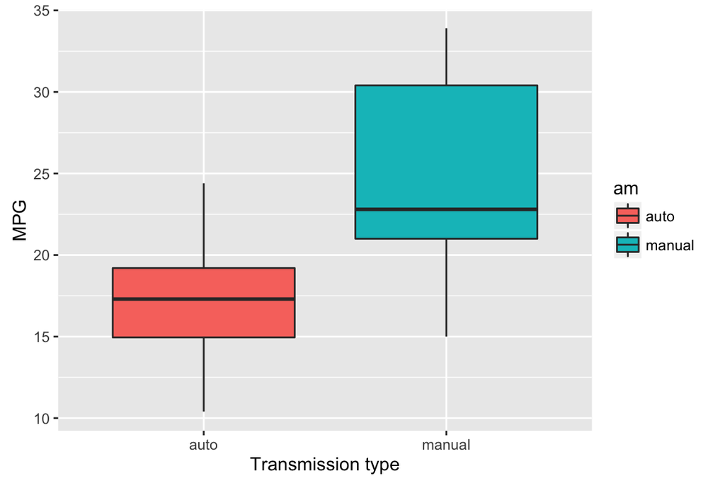

To find out if this increase is statistically significant, we will perform a t-test (assuming that the distribution is normal) with the null hypothesis: mean MPG in cars with automatic transmission is the same as MPG in cars with manual transmission.

```r
t.test(mpg ~ am, data = mtcars)
```

```
##
##  Welch Two Sample t-test
##
## data:  mpg by am
## t = -3.7671, df = 18.332, p-value = 0.001374
## alternative hypothesis: true difference in means is not equal to 0
## 95 percent confidence interval:
##  -11.280194  -3.209684
## sample estimates:
##   mean in group auto mean in group manual
##             17.14737             24.39231
```

With p-value of `0.0014`, we can reject the null hypothesis and see that this difference is significant.

### Linear Regression Model

```r
lin.model <- lm(mpg ~ am, data = mtcars)
summary(lin.model)
```

```
##
## Call:
## lm(formula = mpg ~ am, data = mtcars)
##
## Residuals:
##     Min      1Q  Median      3Q     Max
## -9.3923 -3.0923 -0.2974  3.2439  9.5077
##
## Coefficients:
##             Estimate Std. Error t value Pr(>|t|)
## (Intercept)   17.147      1.125  15.247 1.13e-15 ***
## ammanual       7.245      1.764   4.106 0.000285 ***
## ---
## Signif. codes:  0 '***' 0.001 '**' 0.01 '*' 0.05 '.' 0.1 ' ' 1
##
## Residual standard error: 4.902 on 30 degrees of freedom
## Multiple R-squared:  0.3598, Adjusted R-squared:  0.3385
## F-statistic: 16.86 on 1 and 30 DF,  p-value: 0.000285
```

The intercept coefficient (`17.1474`) is the empirical mean of MPG for cars with automatic transmissions. The `am` coefficient (`7.2449`) is the mean increase of MPG for cars with manual transmissions. The mean MPG for cars with manual transmissions is `intercept` + `am` = `24.3923`.

The p-value is `0.000285`, which means that there is a significant difference in MPG between groups with different transmission. However, the adjusted R-squared is `0.3385`, which means that only ~34% of the variability is explained by this model. This percentage is relatively small, so we should find out which of other variables could be predictors in our model.

### Multivariate Regression Model

To begin with, we will build a model with `mpg` as the outcome and all other variables as predictors. Next, we will use this model as the initial model in the stepwise search by `step` algorithm.

```r
init.model <- lm(mpg ~ ., data = mtcars)
step.model <- step(init.model)
```

```r
summary(step.model)
```

```
##
## Call:
## lm(formula = mpg ~ cyl + hp + wt + am, data = mtcars)
##
## Residuals:
##     Min      1Q  Median      3Q     Max
## -3.9387 -1.2560 -0.4013  1.1253  5.0513
##
## Coefficients:
##             Estimate Std. Error t value Pr(>|t|)
## (Intercept) 33.70832    2.60489  12.940 7.73e-13 ***
## cyl6        -3.03134    1.40728  -2.154  0.04068 *
## cyl8        -2.16368    2.28425  -0.947  0.35225
## hp          -0.03211    0.01369  -2.345  0.02693 *
## wt          -2.49683    0.88559  -2.819  0.00908 **
## ammanual     1.80921    1.39630   1.296  0.20646
## ---
## Signif. codes:  0 '***' 0.001 '**' 0.01 '*' 0.05 '.' 0.1 ' ' 1
##
## Residual standard error: 2.41 on 26 degrees of freedom
## Multiple R-squared:  0.8659, Adjusted R-squared:  0.8401
## F-statistic: 33.57 on 5 and 26 DF,  p-value: 1.506e-10
```

The best model found by the `step` algorithm contains `cyl` (number of cylinders), `hp` (gross horsepower), `wt` (weight), and `am` (transmission) variables. We have compared this model with the linear model (Appendix - Figure: Comparing regression models). From the results, we can tell that there are significant differences between two models, in other words, `cyl`, `hp`, and `wt` variables increase accuracy of the model. With these three variables as confounders, adjusted R-squared is `0.8401`, meaning ~84% of the variability is explained by the model above.

## Appendix

### Figure: Exploratory plots

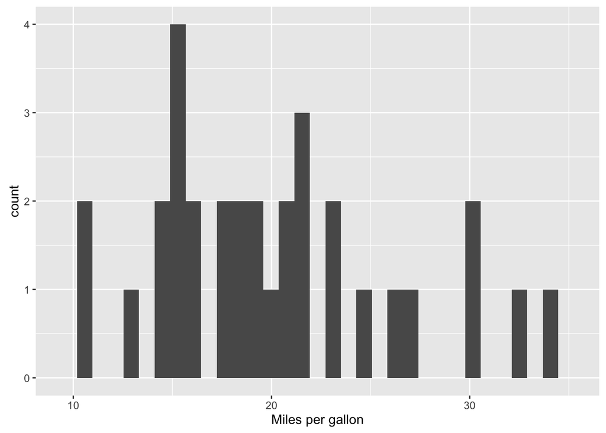

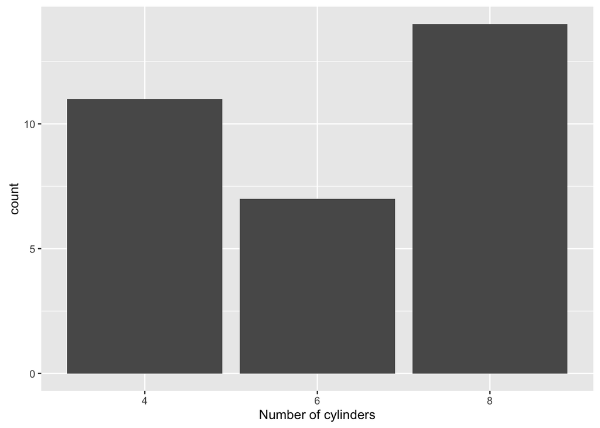

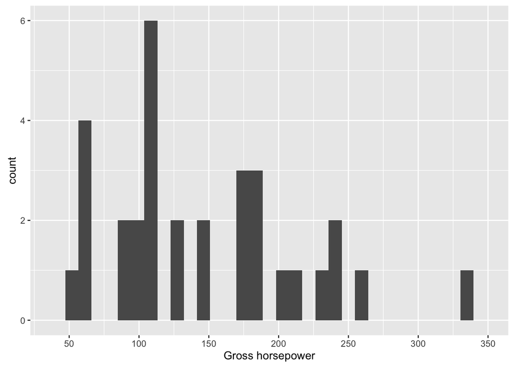

```r
# cor(mtcars)
```

### Figure: Comparing regression models

```r
anova(lin.model, step.model)
```

```
## Analysis of Variance Table
##
## Model 1: mpg ~ am
## Model 2: mpg ~ cyl + hp + wt + am
##   Res.Df    RSS Df Sum of Sq      F    Pr(>F)
## 1     30 720.90
## 2     26 151.03  4    569.87 24.527 1.688e-08 ***
## ---
## Signif. codes:  0 '***' 0.001 '**' 0.01 '*' 0.05 '.' 0.1 ' ' 1
```